#### Find the Lowest-Forecast-RMSE Model in First Differences

Since the professor asks us to estimate in first differences, I’m comparing many models in first differences.

#### 1. Analyze the Frist 80% Training Set of Each Series’ First Difference

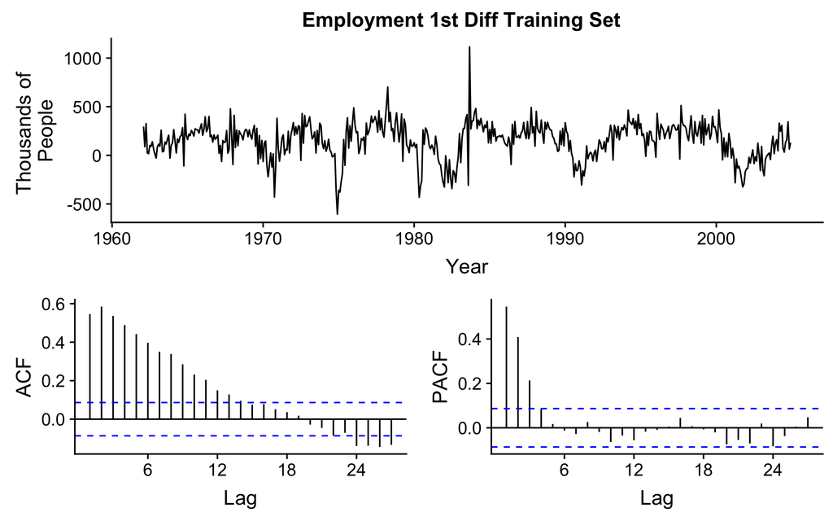

Employment 1st Diff Training Set passes the ADF test under a 5% critical value, but not the Ljung-Box test up to 24 lags. The correlogram suggests an AR(3) effect.

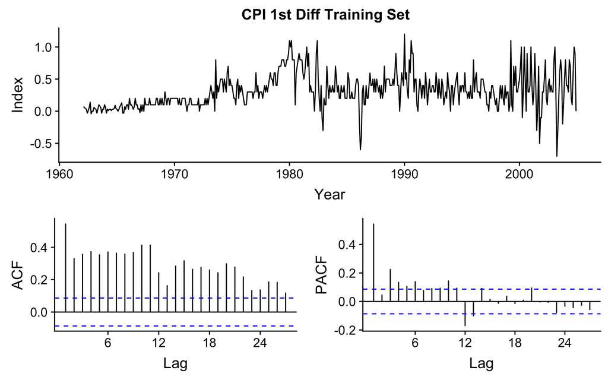

CPI 1st Diff Training Set doesn’t passes the ADF test under a 5% critical value, nor the Ljung-Box test up to 24 lags. The correlogram suggests an AR(1) or AR(3) effect.

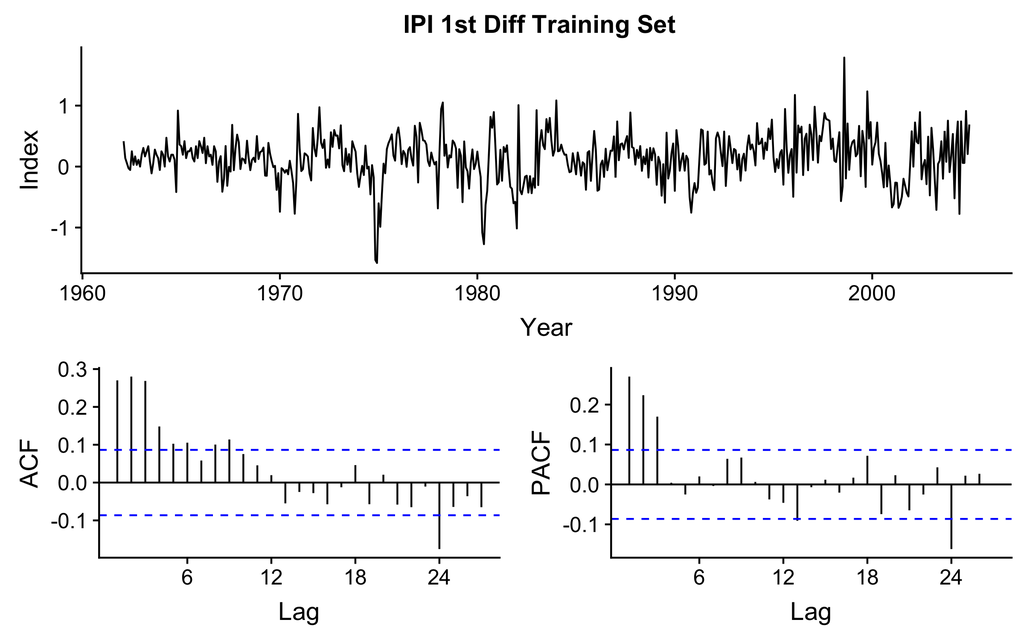

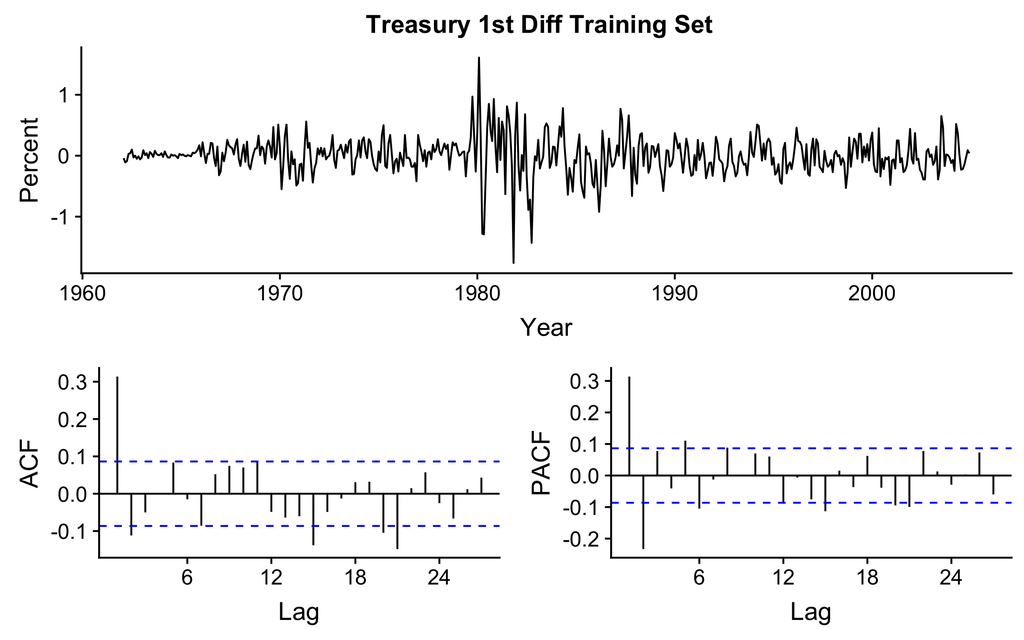